# Kolleg Europa - Social Network Analysis

Datenauswertung Reisediplomatie-Netzwerk

Stefan Haussner

08.07.2019

```r
load("C:/OwnCloud/SH/Workshops_Talks/KollegEuropa_Studienstiftung_Netzwerkanalyse_Prag/R/network_analysis_KollegEuropa/data/data_preprocessed.Rdata")
#load("D:/KollegEuropa_Studienstiftung_Netzwerkanalyse_Prag/R/network_analysis_KollegEuropa/data/data_preprocessed.Rdata")
```

Grundsätzlich sieht das Reisediplomatie-Netzwerk bereits so aus. Limitations bzw. offene Fragen finden sich im `script_datawrangling.Rmd`. Eine größere Abbildung ist mitgeschickt bzw. liegt in “outputs”.

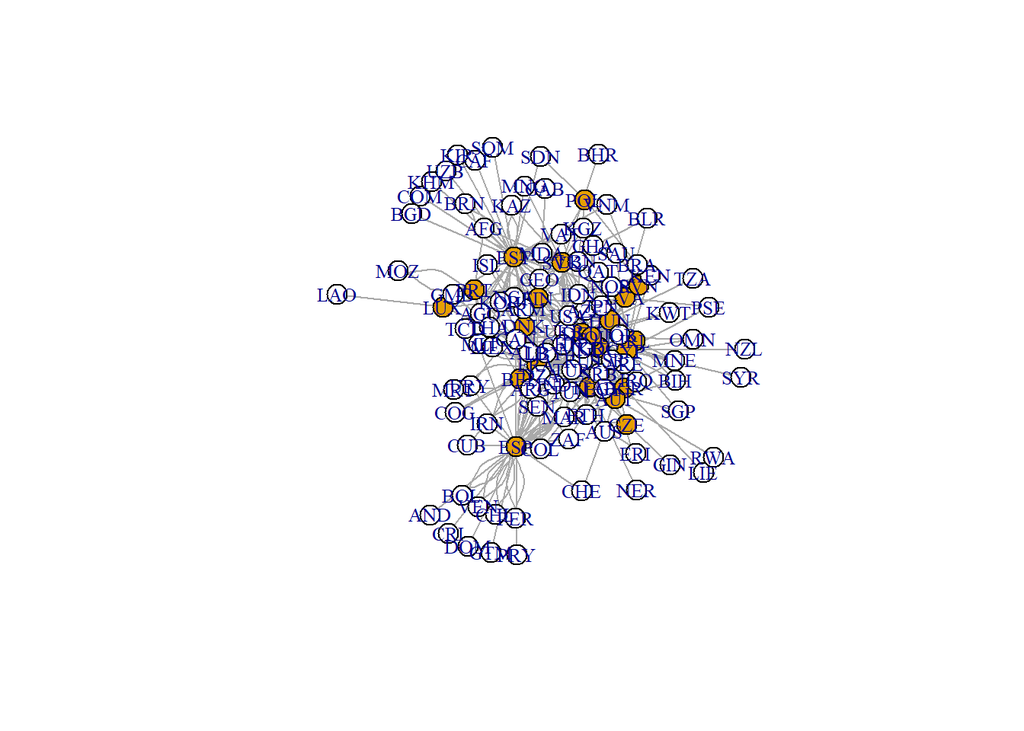

```r
plot.igraph(rd_igraph,
            vertex.color = V(rd_igraph)$type,
            vertex.label.cex = 0.8,
            vertex.size = 10)
```

# Analyse des Two-Mode-Netzwerks

Es gibt verschiedene Ansätze für die Analyse von Zugehörigkeitsdaten, ohne die Umwandlung in `Co-Affiliation-Netze` (Projections). Da Zugehörigkeitsgraphen auch Graphen sind, liegt der naheliegende Ansatz darin, einfach alle Standardalgorithmen und -techniken des Netzwerkanalyse-Toolkits zu verwenden, die für normale Netze im Allgemeinen gelten.

Dabei gehen wir entweder davon aus, dass die spezielle Natur von Affiliationsnetzen die Techniken nicht beeinflusst, oder wir können vorgeben, dass Bindungen innerhalb von Knotensätzen aufgetreten sein könnten und einfach nicht aufgetreten sind. Dieser Ansatz funktioniert für eine kleine Klasse von Methoden, jedoch keineswegs für alle.

Ein alternativer Ansatz besteht darin, neue Metriken und Algorithmen zu entwickeln, die speziell für den TwoMode-Fall designed wurden. Das hört sich nach viel mehr Arbeit an, aber in der Praxis ist es oft möglich, Metriken anzupassen, die für allgemeine Diagramme ausgelegt sind, indem einfach eine entsprechende Post-hoc-Normalisierung angewendet wird. Besonders bei Zentralitätsmaßen ist das meist der bessere Weg.[^1]

Im Degree-Fall ist es nicht sinnvoll, den einfachen Grad (Anzahl aller Verbindungen des Knotens) zu zählen und daraus die Dichte zu errechnen. Denn zwischen den Knoten einer Gruppe können ja gar keine Verbindungen bestehen. Eine sinnvolle Änderung ist es also, wenn die Dichte auf der Grundlage der Verbindungen besteht, die der Knoten mit der Gruppe des anderen Typs aufweist.

```r
density_bipartite <- function(graph) {
  if (is.directed(graph)) {
    ecount(graph) / sum(V(graph)$type) / sum(!V(graph)$type) / 2.0}
  else {
    ecount(graph) / sum(V(graph)$type) / sum(!V(graph)$type)
  }
}

edge_density(rd_igraph)
```

```
## [1] 0.05620745
```

```r
density_bipartite(rd_igraph)
```

```
## [1] 0.1837121
```

Auch bei der Closeness-Zentralität bietet sich eine Anpassung an. Diese wurde an dieser Stelle in ein externes Script ausgelagert (`bipartite_closeness_centrality.R`) und kann dort bei Bedarf nachvollzogen werden.

> Erinnerung `Closeness`: mittlere Entfernung von einem Scheitelpunkt zu anderen Scheitelpunkten.

```r
source("bipartite_closeness_centrality.R")

bipartite_closeness_centrality(rd_igraph)
```

```
## $Bipartite.Closeness.Centrality
##   [1] 0.4339623 0.4233129 0.4964029 0.5348837 0.4539474 0.5227273 0.4367089
##   [8] 0.4259259 0.4726027 0.4233129 0.3770492 0.4394904 0.3650794 0.4058824
##  [15] 0.4726027 0.4539474 0.3854749 0.4791667 0.3812155 0.4285714 0.4893617
##  [22] 0.4509804 0.6272189 0.7571429 0.6838710 0.6973684 0.8281250 0.8091603
##  [29] 0.6883117 0.6235294 0.7114094 0.5698925 0.6973684 0.6309524 0.4884793
##  [36] 0.7851852 0.8091603 0.7066667 0.6666667 0.6838710 0.5921788 0.6928105
##  [43] 0.7260274 0.6057143 0.7210884 0.6385542 0.7162162 0.6928105 0.5638298
##  [50] 0.6091954 0.6838710 0.6347305 0.5380711 0.6751592 0.7066667 0.5729730
##  [57] 0.6385542 0.5668449 0.5729730 0.5668449 0.6127168 0.7162162 0.6503067
##  [64] 0.5668449 0.6463415 0.6583851 0.5668449 0.5668449 0.5792350 0.5668449
##  [71] 0.6503067 0.7066667 0.5668449 0.5856354 0.6272189 0.6625000 0.5856354
##  [78] 0.5955056 0.6666667 0.5668449 0.6022727 0.5668449 0.5760870 0.5047619
##  [85] 0.7310345 0.6127168 0.6127168 0.5578947 0.6463415 0.6127168 0.6127168
##  [92] 0.5463918 0.5196078 0.6272189 0.5196078 0.5196078 0.5760870 0.5300000
##  [99] 0.5170732 0.5492228 0.4398340 0.5549738 0.4930233 0.4649123 0.5729730
## [106] 0.5047619 0.5247525 0.5247525 0.5247525 0.5247525 0.5247525 0.5247525
## [113] 0.5247525 0.5247525 0.5247525 0.5326633 0.5326633        NA
```

```r
bipartite_closeness_centrality(rd_igraph) %>% unlist() %>% unname() %>% round(3) %>% as_tibble() %>%
  mutate(name = V(rd_igraph)$name,
         type = case_when(V(rd_igraph)$type == TRUE ~ "eu",
                          TRUE ~ "non-eu")) %>%
  select(name, closeness_centrality = value, type) %>%
  arrange(type, -closeness_centrality) %>%
  datatable(options = list(pageLength = 20))
```

|  | name | closeness_centrality | type |
| --- | --- | --- | --- |
| 1 | DEU | 0.535 | eu |
| 2 | FIN | 0.523 | eu |
| 3 | DNK | 0.496 | eu |
| 4 | HUN | 0.489 | eu |
| 5 | SVN | 0.479 | eu |
| 6 | IRL | 0.473 | eu |
| 7 | PRT | 0.473 | eu |
| 8 | EST | 0.454 | eu |
| 9 | ROU | 0.454 | eu |
| 10 | CYP | 0.451 | eu |

[output cut: 108 more lines]

Gleiches gilt für die Betweenness-Zentralität.

> Erinnerung `Betweenness`: Ausmaß, in dem ein Knoten auf Pfaden zwischen anderen Knoten liegt.

```r
source("bipartite_betweenness_centrality.R")

bipartite_betweenness_centrality(rd_igraph)
```

```
## $Bipartite.Betweenness.Centrality
##   [1] 0.0248786549 0.0036404479 0.1320341478 0.2637220107 0.0524815915
##   [6] 0.1753025990 0.0057062954 0.0079058106 0.1041289775 0.0111911090
##  [11] 0.0186995708 0.0323326410 0.0034020680 0.0213959582 0.0627606618
##  [16] 0.0572977658 0.0043486485 0.1939814689 0.0003755403 0.0055730577
##  [21] 0.1258035791 0.0363974156 0.0030343580 0.0122523031 0.0107651090
##  [26] 0.0063533412 0.0460573327 0.0438039333 0.0097388188 0.0024166499
##  [31] 0.0099631010 0.0001778301 0.0142953687 0.0033770228 0.0000000000
##  [36] 0.0324909209 0.0455377090 0.0198076256 0.0085988007 0.0229789699
##  [41] 0.0017195600 0.0310713268 0.0321853872 0.0033836937 0.0284534892
##  [46] 0.0044945089 0.0745586198 0.0150896679 0.0002543492 0.0008467917
##  [51] 0.0155889316 0.0042181432 0.0000000000 0.0080471561 0.0165539172
##  [56] 0.0001575381 0.0012583719 0.0000000000 0.0014621575 0.0000000000
##  [61] 0.0011120763 0.0128876459 0.0015997828 0.0000000000 0.0049879487
##  [66] 0.0071090870 0.0000000000 0.0000000000 0.0016097023 0.0000000000
##  [71] 0.0031995656 0.0105941863 0.0000000000 0.0006962158 0.0064595889
##  [76] 0.0055906786 0.0013924315 0.0023127856 0.0041320031 0.0000000000
##  [81] 0.0020888246 0.0013974317 0.0008836614 0.0000000000 0.0233428538
##  [86] 0.0022583771 0.0006566243 0.0000000000 0.0033330830 0.0011291886
##  [91] 0.0014971397 0.0005545896 0.0000000000 0.0130236349 0.0000000000
##  [96] 0.0000000000 0.0007133842 0.0017132027 0.0002098001 0.0006687473
## [101] 0.0000000000 0.0019985289 0.0000000000 0.0000000000 0.0003956719
## [106] 0.0000000000 0.0000000000 0.0000000000 0.0000000000 0.0000000000
## [111] 0.0000000000 0.0000000000 0.0000000000 0.0000000000 0.0000000000
## [116] 0.0000000000 0.0000000000           NA
```

```r
bipartite_betweenness_centrality(rd_igraph) %>% unlist() %>% unname() %>% round(3) %>% as_tibble() %>%
  mutate(name = V(rd_igraph)$name,
         type = case_when(V(rd_igraph)$type == TRUE ~ "eu",
                          TRUE ~ "non-eu")) %>%
  select(name, betweenness_centrality = value, type) %>%
  arrange(type, -betweenness_centrality) %>%
  datatable(options = list(pageLength = 20))
```

|  | name | betweenness_centrality | type |
| --- | --- | --- | --- |
| 1 | DEU | 0.264 | eu |
| 2 | SVN | 0.194 | eu |
| 3 | FIN | 0.175 | eu |
| 4 | DNK | 0.132 | eu |
| 5 | HUN | 0.126 | eu |
| 6 | IRL | 0.104 | eu |
| 7 | PRT | 0.063 | eu |
| 8 | ROU | 0.057 | eu |
| 9 | EST | 0.052 | eu |
| 10 | CYP | 0.036 | eu |

[output cut: 108 more lines]

# Analyse der One-Mode-Projektionen

Die gemeinsame Untersuchung beider Knotentypen in einer Two-Mode-Netzwerkgrafik ist häufig der erste Schritt beim Studium eines Zugehörigkeitsnetzwerks. Es ist jedoch auch sinnvoll die `One-Mode-Projektionen` des Netzwerks zu untersuchen. Die Funktion `bipartite.projection` gibt eine Liste von zwei igraph-Netzwerkobjekten zurück. Das erste Netzwerk besteht aus direkten Verbindungen zwischen dem ersten Modus und das zweite Netzwerk zeigt die Verbindungen zwischen dem zweiten Modus. In unserem Fall also ein Netzwerk aller EU28-Länder und ein Netzwerk aller Gastgeberländer.

```r
rd_projection <- bipartite.projection(rd_igraph)
rd_projection
```

```
## $proj1
## IGRAPH 8f7e761 UNW- 96 2115 --
## + attr: name (v/c), weight (e/n)
## + edges from 8f7e761 (vertex names):
##  [1] RUS--SEN RUS--ALB RUS--SRB RUS--ARM RUS--DZA RUS--CAN RUS--AGO
##  [8] RUS--ZAF RUS--ARG RUS--COG RUS--TUR RUS--AZE RUS--LIE RUS--UKR
## [15] RUS--CHN RUS--ARE RUS--EGY RUS--ISR RUS--MNE RUS--MAR RUS--GEO
## [22] RUS--ISL RUS--IND RUS--JOR RUS--USA RUS--LBN RUS--GHA RUS--NGA
## [29] RUS--MKD RUS--ETH RUS--TZA RUS--JPN RUS--KOR RUS--KWT RUS--IRQ
## [36] RUS--MLI RUS--GMB RUS--TCD RUS--TUN RUS--IRN RUS--AUS RUS--MRT
## [43] RUS--COL RUS--CUB RUS--MEX RUS--NOR RUS--IDN RUS--THA RUS--ERI
## [50] RUS--LBY RUS--NER RUS--GIN RUS--SGP RUS--BRA RUS--BIH RUS--CHE
## + ... omitted several edges
##
## $proj2
## IGRAPH 8f7e761 UNW- 22 191 --
## + attr: name (v/c), weight (e/n)
## + edges from 8f7e761 (vertex names):
##  [1] BEL--BGR BEL--DNK BEL--DEU BEL--FRA BEL--GRC BEL--ITA BEL--AUT
##  [8] BEL--SVN BEL--HUN BEL--EST BEL--ROU BEL--ESP BEL--IRL BEL--CYP
## [15] BEL--SVK BEL--FIN BEL--PRT BGR--DNK BGR--DEU BGR--FRA BGR--GRC
## [22] BGR--ITA BGR--AUT BGR--SVN BGR--HUN BGR--IRL BGR--CYP BGR--ROU
## [29] BGR--SVK BGR--ESP BGR--EST BGR--FIN BGR--CZE DNK--DEU DNK--FRA
## [36] DNK--GRC DNK--ITA DNK--AUT DNK--SVN DNK--HUN DNK--EST DNK--ROU
## [43] DNK--ESP DNK--CYP DNK--FIN DNK--SVK DNK--LVA DNK--LUX DNK--POL
## [50] DEU--FRA DEU--GRC DEU--ITA DEU--AUT DEU--SVN DEU--HUN DEU--EST
## + ... omitted several edges
```

```r
rd_hosts <- rd_projection$proj1
rd_eu28 <- rd_projection$proj2
```

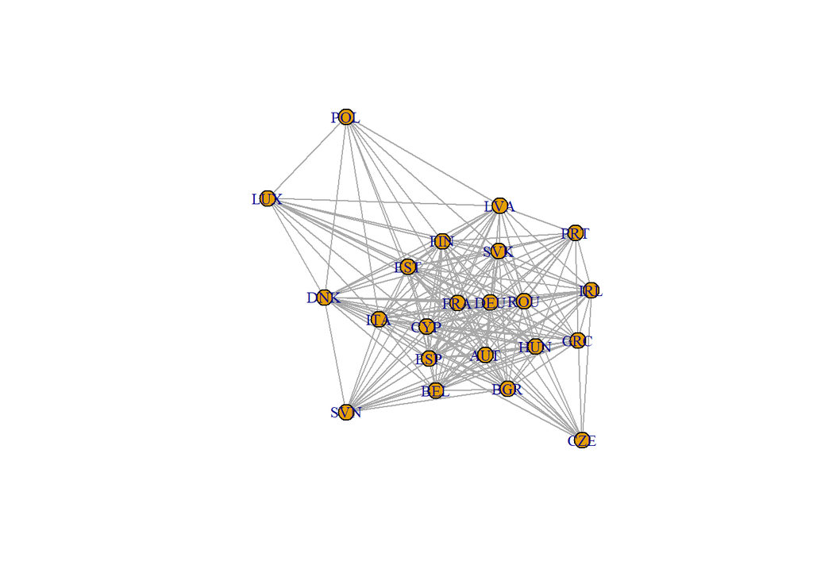

```r
plot.igraph(rd_eu28,
            vertex.label.cex = 0.8,
            vertex.size = 10)
```

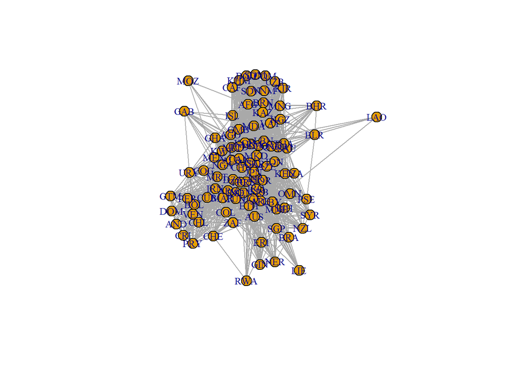

```r
plot.igraph(rd_hosts,
            vertex.label.cex = 0.8,
            vertex.size = 10)
```

# Analyse des EU28-Netzwerks

Das EU28-Netzwerk ist ein `Co-occurence-Netzwerk` (One-Mode-Projektion des ursprünglichen Reisediplomatienetzwerks). Zwei Länder der EU28 haben dann eine Verbindung, wenn sie das gleiche Gastland besucht haben. Das Netzwerk ist ein ungerichtetes Netzwerk.

## Distances and paths

```r
farthest_vertices(rd_eu28)
```

```
## $vertices
## + 2/22 vertices, named, from 8f7e761:
## [1] BEL DEU
##
## $distance
## [1] 5
```

```r
diameter(rd_eu28)
```

```
## [1] 5
```

```r
mean_distance(rd_eu28, directed=FALSE)
```

```
## [1] 1.17316
```

## edge density

```r
edge_density(rd_eu28)
```

```
## [1] 0.8268398
```

## Welche Länder sind im Netzwerk besonders auffallend?

Es ist intuitiv sinnvoll, dass ein Netzwerkmitglied, das mit vielen anderen Mitgliedern des Netzwerks verbunden ist, eine herausragende Position einnimmt. Für nicht gerichtete Netzwerke sprechen wir von Akteuren mit einer hohen Zentralität. Es gibt jedoch eine Reihe von Möglichkeiten, diese Art der Zentralität zu operationalisieren. Tatsächlich stehen in der Sozialen Netzwerkanalyse Dutzende von Zentralitätsstatistiken zur Verfügung.

### Degree centrality

> Erinnerung degree: Anzahl, wie viele Nachbarn ein Knoten hat.

```r
degree(rd_eu28)
```

```
## BEL BGR DNK DEU EST FIN FRA GRC IRL ITA LVA LUX AUT POL PRT ROU SVK SVN
##  17  17  18  21  21  19  21  19  17  20  18  11  19   9  14  20  19  14
## ESP CZE HUN CYP
##  18  11  19  20
```

```r
r_degree <- degree(rd_eu28)

data.frame(r_degree)
```

```
##     r_degree
## BEL       17
## BGR       17
## DNK       18
## DEU       21
## EST       21
## FIN       19
## FRA       21
## GRC       19
## IRL       17
## ITA       20
## LVA       18
## LUX       11
## AUT       19
## POL        9
## PRT       14
## ROU       20
## SVK       19
## SVN       14
## ESP       18
## CZE       11
## HUN       19
## CYP       20
```

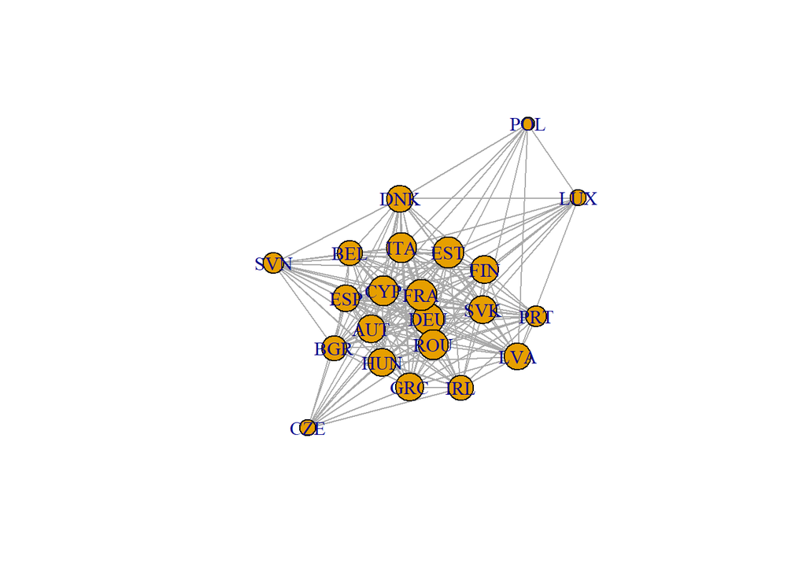

```r
plot.igraph(rd_eu28,
            vertex.size = r_degree)
```

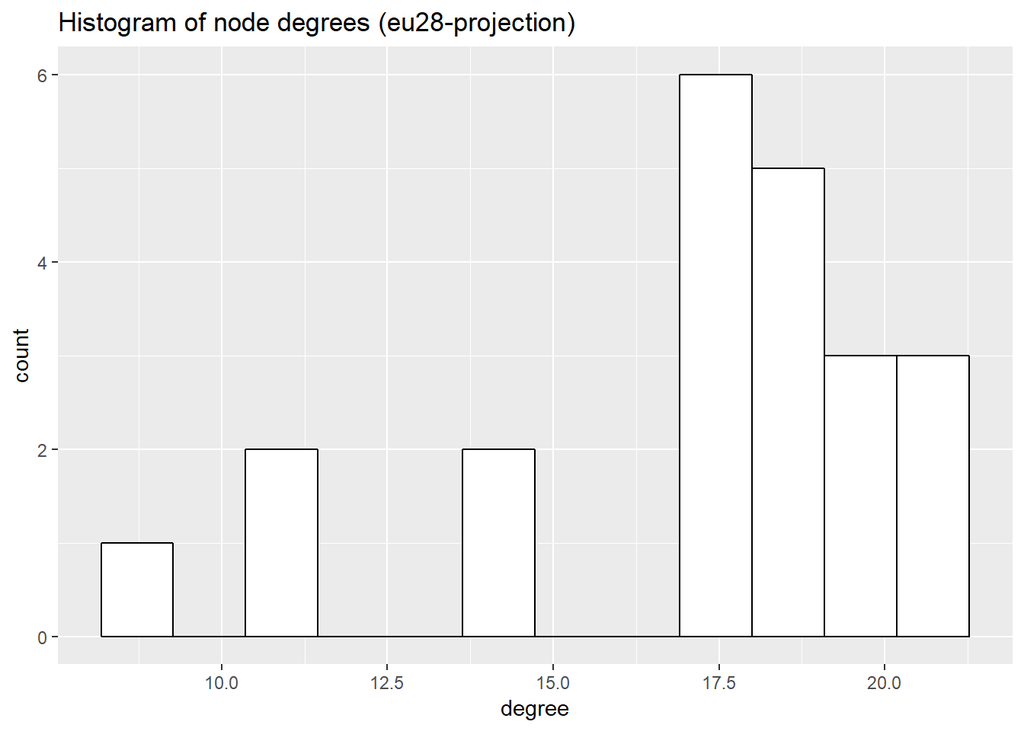

```r
ggplot() +
  aes(r_degree)+
  geom_histogram(bins = 12, colour="black", fill="white")+
  labs(title = "Histogram of node degrees (eu28-projection)",
       x = "degree")
```

### Closeness Centrality

> Erinnerung closeness: mittlere Entfernung von einem Scheitelpunkt zu anderen Scheitelpunkten

```r
r_closeness <- closeness(rd_eu28)
data.frame(r_closeness)
```

```
##     r_closeness
## BEL  0.01587302
## BGR  0.01449275
## DNK  0.02127660
## DEU  0.01234568
## EST  0.01818182
## FIN  0.01639344
## FRA  0.01886792
## GRC  0.01724138
## IRL  0.01851852
## ITA  0.02127660
## LVA  0.02380952
## LUX  0.02000000
## AUT  0.01562500
## POL  0.02272727
## PRT  0.01666667
## ROU  0.01666667
## SVK  0.01449275
## SVN  0.01960784
## ESP  0.01694915
## CZE  0.01851852
## HUN  0.01666667
## CYP  0.01538462
```

### Betweenness

> Erinnerung betweenness: Ausmaß, in dem ein Knoten auf Pfaden zwischen anderen Knoten liegt.

```r
r_betweenness <- igraph::betweenness(rd_eu28)
data.frame(r_betweenness)
```

```
##     r_betweenness
## BEL     6.8809524
## BGR     1.7000000
## DNK    20.8095238
## DEU     0.0000000
## EST     3.2214286
## FIN     5.0238095
## FRA     4.6333333
## GRC     2.6714286
## IRL    16.9619048
## ITA    21.2428571
## LVA    34.5738095
## LUX    20.4261905
## AUT     0.4047619
## POL    32.7976190
## PRT     2.4166667
## ROU     0.6666667
## SVK     5.1666667
## SVN    16.3666667
## ESP     7.2095238
## CZE    18.3404762
## HUN     3.2095238
## CYP     5.6880952
```

### Eigenvector-Centrality

> Erinnerung eigenvector: Ein Knoten ist wichtig, wenn er mit anderen wichtigen Knoten verbunden ist.

```r
r_eigen <- eigen_centrality(rd_eu28)
data.frame(r_eigen$vector)
```

```
##     r_eigen.vector
## BEL     0.27917601
## BGR     0.33773386
## DNK     0.17587614
## DEU     1.00000000
## EST     0.37628923
## FIN     0.37025256
## FRA     0.82330977
## GRC     0.35973090
## IRL     0.33635748
## ITA     0.36559702
## LVA     0.24345619
## LUX     0.05806097
## AUT     0.42376102
## POL     0.04074457
## PRT     0.23803869
## ROU     0.50504731
## SVK     0.46515657
## SVN     0.10835049
## ESP     0.39662868
## CZE     0.10491785
## HUN     0.38936992
## CYP     0.42071089
```

Alle Ergebnisse gesammelt und in sortierbarer Tabelle:

```r
results_df <- data.frame(r_degree,r_closeness, r_betweenness, r_eigen$vector) %>%
  rownames_to_column() %>% as_tibble() %>%
  mutate_if(is.numeric, round, 4) %>%
  arrange(rowname)

datatable(results_df, options = list(pageLength = 20))
```

|  | rowname | r_degree | r_closeness | r_betweenness | r_eigen.vector |
| --- | --- | --- | --- | --- | --- |
| 1 | AUT | 19 | 0.0156 | 0.4048 | 0.4238 |
| 2 | BEL | 17 | 0.0159 | 6.881 | 0.2792 |
| 3 | BGR | 17 | 0.0145 | 1.7 | 0.3377 |
| 4 | CYP | 20 | 0.0154 | 5.6881 | 0.4207 |
| 5 | CZE | 11 | 0.0185 | 18.3405 | 0.1049 |
| 6 | DEU | 21 | 0.0123 | 0 | 1 |
| 7 | DNK | 18 | 0.0213 | 20.8095 | 0.1759 |
| 8 | ESP | 18 | 0.0169 | 7.2095 | 0.3966 |
| 9 | EST | 21 | 0.0182 | 3.2214 | 0.3763 |
| 10 | FIN | 19 | 0.0164 | 5.0238 | 0.3703 |

[output cut: 12 more lines]

```r
t_cor <- results_df %>%
  select(-1) %>%
  as.matrix() %>%
  cor() %>%
  melt()
```

## Subgroups and communities

### Transitivität

```r
transitivity(rd_eu28)
```

```
## [1] 0.8778462
```

### Größte Clique

```r
#cliques(rd_eu28) # list of cliques
largest_cliques(rd_eu28)
```

```
## [[1]]
## + 15/22 vertices, named, from 8f7e761:
##  [1] DEU EST FRA ITA FIN ROU GRC AUT HUN BEL BGR CYP IRL SVK ESP
##
## [[2]]
## + 15/22 vertices, named, from 8f7e761:
##  [1] DEU EST FRA ITA FIN ROU GRC AUT HUN BEL BGR CYP DNK SVK ESP
```

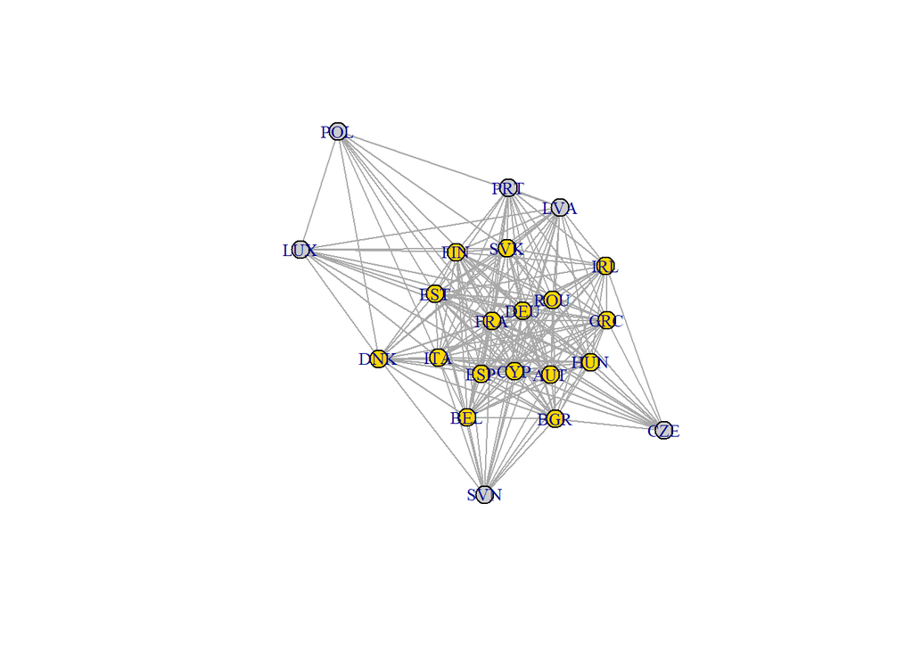

```r
vcol <- rep("grey80", vcount(rd_eu28))
vcol[unlist(largest_cliques(rd_eu28))] <- "gold"
plot(as.undirected(rd_eu28), vertex.label=V(rd_eu28)$name, vertex.color=vcol,
     vertex.label.cex = 0.8,
     vertex.size = 10)
```

### Community detection

```r
ceb <- cluster_edge_betweenness(rd_eu28)
```

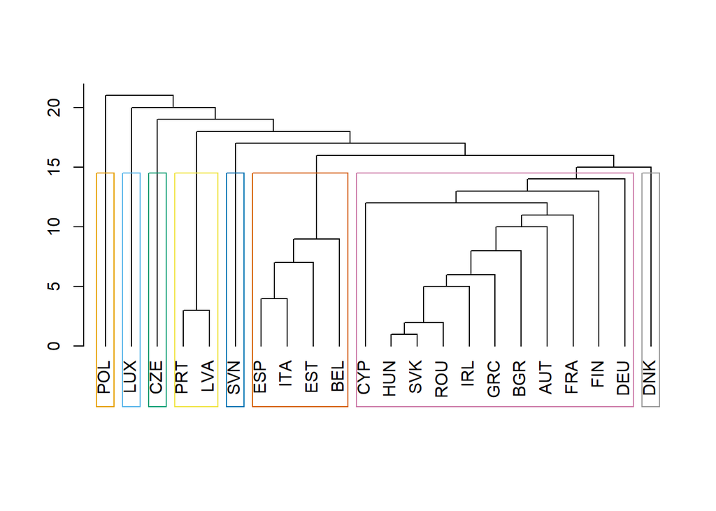

```r
cle <- cluster_leading_eigen(rd_eu28)

dendPlot(ceb, mode="hclust")
```

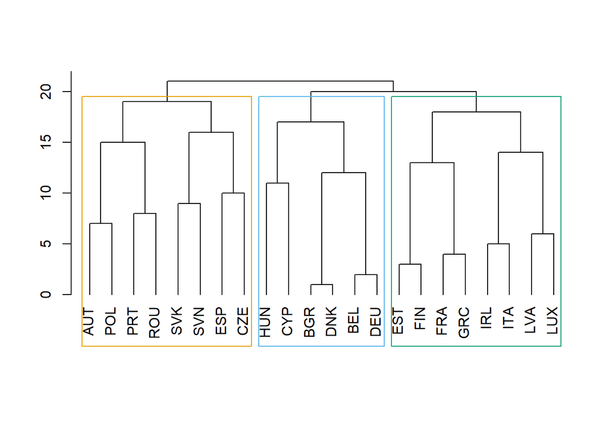

```r
dendPlot(cle, mode="hclust")
```

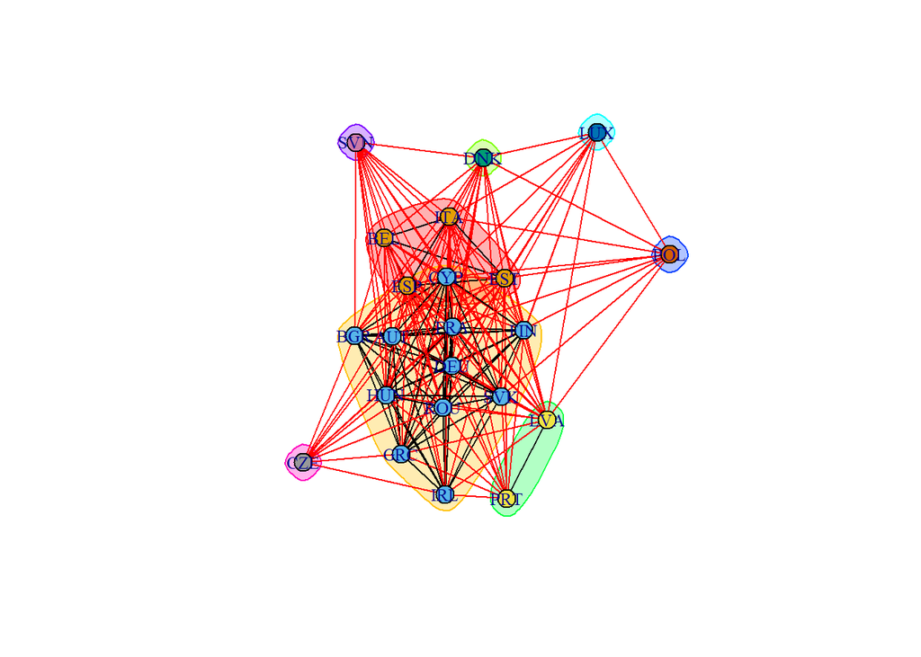

```r
plot(ceb,rd_eu28,
     vertex.label.cex = 0.8,
     vertex.size = 10)
```

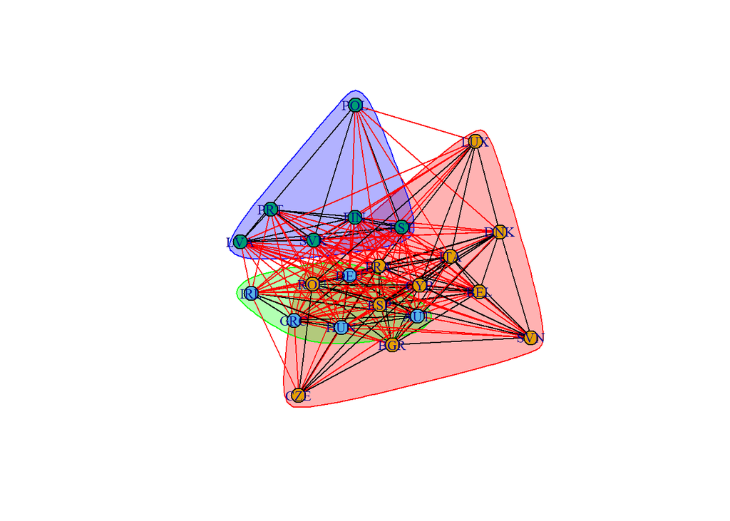

```r
plot(cle,rd_eu28,
     vertex.label.cex = 0.8,
     vertex.size = 10)
```

# Exponential Random Graph Models

Wie “besonders” sind unsere Projektionsnetzwerke, im Vergleich zu ähnlich aufgebauten Netzwerken?

```r
g_random <- vector('list',1000)

for(i in 1:1000){

  g_random[[i]] <- sample_gnp(n = gorder(rd_eu28),
                              p = edge_density(rd_eu28),
                              directed = FALSE)
}

# apply mean_distance on every graph
g_random_meandis <- unlist(lapply(g_random, mean_distance, directed = FALSE))

mean_distance(rd_eu28, directed = FALSE)
```

```
## [1] 1.17316
```

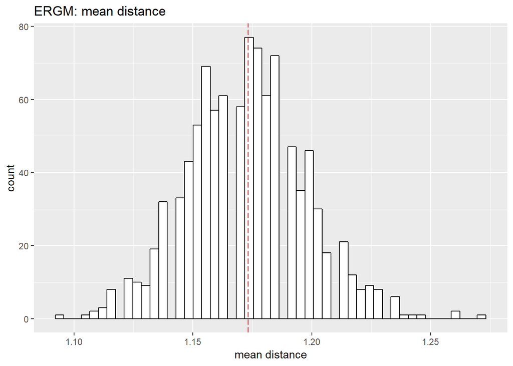

```r
# graphical comparison to original network
ggplot() +
  aes(g_random_meandis)+
  geom_histogram(bins = 50, colour="black", fill="white")+
  geom_vline(xintercept = mean_distance(rd_eu28, directed = FALSE), colour="red", linetype = "longdash")+
  labs(title = "ERGM: mean distance",
       x = "mean distance")
```

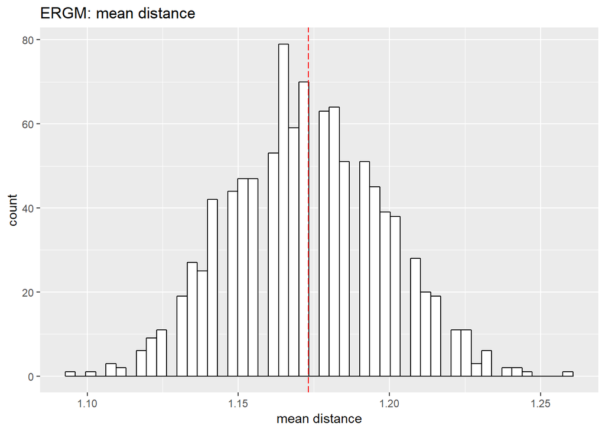

```r
g_random <- vector('list',1000)

for(i in 1:1000){

  g_random[[i]] <- sample_gnp(n = gorder(rd_eu28),
                              p = edge_density(rd_eu28),
                              directed = FALSE)
}

# apply mean_distance on every graph
g_random_meandis <- unlist(lapply(g_random, mean_distance, directed = FALSE))

g_random_diameter <- unlist(lapply(g_random, diameter, directed = FALSE))

g_random_transitivity <- unlist(lapply(g_random, transitivity))

ggplot() +
  aes(g_random_meandis)+
  geom_histogram(bins = 50, colour="black", fill="white")+
  geom_vline(xintercept = mean_distance(rd_eu28, directed = FALSE), colour="red", linetype = "longdash")+
  labs(title = "ERGM: mean distance",
       x = "mean distance")
```

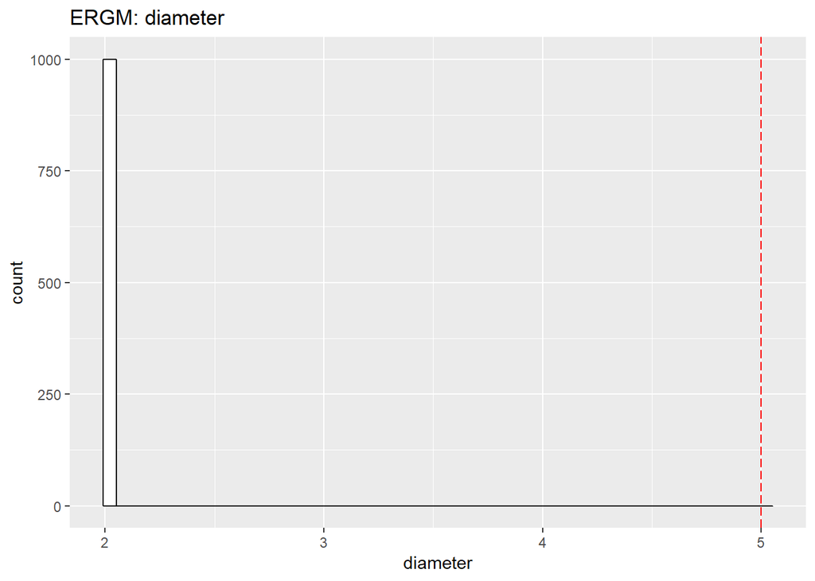

```r
ggplot() +
  aes(g_random_diameter)+
  geom_histogram(bins = 50, colour="black", fill="white")+
  geom_vline(xintercept = diameter(rd_eu28, directed = FALSE), colour="red", linetype = "longdash")+
  labs(title = "ERGM: diameter",
       x = "diameter")
```

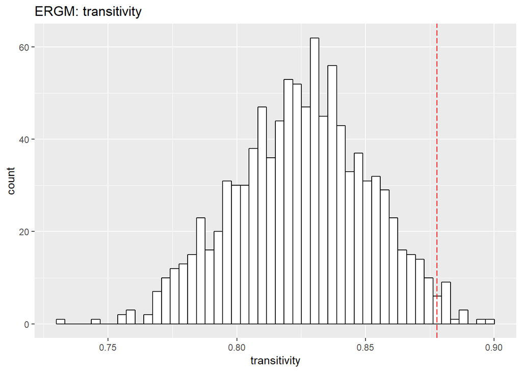

```r
ggplot() +
  aes(g_random_transitivity)+
  geom_histogram(bins = 50, colour="black", fill="white")+
  geom_vline(xintercept = transitivity(rd_eu28), colour="red", linetype = "longdash")+
  labs(title = "ERGM: transitivity",
       x = "transitivity")
```

[^1]: 1: Theoretische und mathematische Hintergründe zu der Normalisierung von Netzwerkmaßen für bipartite Netzwerke findet man in Scott/Carrington: The SAGE Handbook of Social Network Analysis, 2011, S. 425f